# DTW distance

Last updated: 2025-11-24

```r
library(tidyverse)
library(plotrix)    #std.error
library(hypr)       #for generating contrast coding
library(ggh4x)
library(ggthemes)
library(DiagrammeR) #grViz for causal diagrams
library(plotly)     #ggplotly for interactive plots
library(ggExtra)    #ggMarginal
library(brms)       #bayesian regression
library(bayestestR) #p_direction, hdi
library(tidybayes)  #add_epred_draws
library(emmeans)
library(doParallel) #set the number of cores
library(svglite)


### Set global options
options(digits = 3) # set the default number of digits to 3
cores = as.integer(detectCores(logical = FALSE) * 0.7) # set the number of cores to use
registerDoParallel(cores=cores) # register the number of cores to use for parallel processing
options(mc.cores = cores)
options(brms.backend = "cmdstanr")  #this will speed up the model fitting

### MCMC options
niter = 20000  #number of iterations
nwu = 2000 #number of warmups

### Rmd settings
knitr::opts_chunk$set(echo=TRUE, warning=FALSE, message=FALSE, fig.path="figures_md/speakerB/dtw/")
```

```r
### Custom functions

########### pp_check_each_round ############
pp_check_each_round <- function(m, data, round_info) {
  df_sub = filter(data, round == round_info)
  p = pp_check(m,
               type = "bars",
               ndraws = 100,
               newdata = df_sub) +
    coord_cartesian(xlim = c(0, 10)) +
    ggtitle(round_info)
  return(p)
}


########### pp_check_each_condition ############
pp_check_each_condition <- function(m, data, condition_info) {
  df_sub = filter(data, condition == condition_info)
  p = pp_check(m,
               type = "bars",
               ndraws = 100,
               newdata = df_sub) +
    coord_cartesian(xlim = c(0, 10)) +
    ggtitle(condition_info)
  return(p)
}


########### plot_posterior ############
plot_posterior <- function(model, model2=NA, interaction=FALSE, include_intercept=FALSE,
                           xlim_cond=0.3, xlim_round=0.06){
  ### extract the posterior draws
  posterior_beta1 <- model %>%
    gather_draws(`b_.*`, regex = TRUE) %>%
    mutate(intercept = str_detect(.variable, "Intercept"),
           component = ifelse(str_detect(.variable, ":"), "Interaction",
                              ifelse(str_detect(.variable, "round"), "Round",
                                     ifelse(str_detect(.variable, "Intercept"), "Intercept",
                                            "Visibility"))))

  if (length(model2) == 1){ #if model2 is NA
    posterior_beta = posterior_beta1
  } else {
    posterior_beta2 <- model2 %>%
      gather_draws(`b_.*`, regex = TRUE) %>%
      filter(.variable == "b_condition_sumAO_Sym") %>%
      mutate(component = "Visibility")

    posterior_beta = rbind(posterior_beta1, posterior_beta2)
  }

  if (include_intercept == F){
    posterior_beta = posterior_beta %>% filter(component != "Intercept")
  }

  posterior_beta = posterior_beta %>%
    mutate(.variable = recode(.variable,
                              "b_Intercept" = "Intercept",
                              "b_conditionAsymAV" = "SymAV--AsymAV",
                              "b_conditionAO" = "SymAV--AO",
                              "b_conditionAsym_Sym" = "AsymAV--SymAV",
                              "b_conditionAO_Asym" = "AO--AsymAV",
                              "b_condition_sumAO_Sym" = "AO--SymAV",
                              "b_round_c" = "Round",
                              "b_log_round_c" = "Centered log(round)",
                              "b_conditionAsym_Sym:round_c" = "Round: Asym--Sym",
                              "b_conditionAO_Sym:round_c" = "Round: AO--Sym",
                              "b_conditionAO_Asym:round_c" = "Round: AO--Asym",
                              "b_conditionAsym_Sym:log_round_c" = "Centered log(round): Asym--Sym",
                              "b_conditionAO_Sym:log_round_c" = "Centered log(round): AO--Sym",
                              "b_conditionAO_Asym:log_round_c" = "Centered log(round): AO--Asym"),
           .variable = factor(.variable,
                              levels = c("AO--SymAV", "AO--AsymAV", "AsymAV--SymAV",
                                         "Round")),
           component = factor(component,
                              levels = c("Intercept", "Visibility", "Round", "Interaction")))


  ### change variables if only main effects are plotted
  if (interaction == F) {
    posterior_beta = filter(posterior_beta, !str_detect(.variable, ":"))
    fill_manual_values = c("steelblue", "steelblue")
  } else{
    fill_manual_values = c("steelblue", "steelblue", "steelblue")
  }


  ### plot the posterior distributions
  p_posterior = ggplot(posterior_beta,
                       aes(x = .value, y = fct_rev(.variable),
                           fill = component)) +
    geom_vline(xintercept = 0, size = 1) +
    stat_halfeye(aes(slab_alpha = intercept),
                 normalize = "panels",
                 slab_alpha = 0.5,
                 .width = c(0.89, 0.95),
                 point_interval = "median_hdi") +
    scale_fill_manual(values = fill_manual_values) +
    scale_slab_alpha_discrete(range = c(0.8, 0.4)) +
    guides(fill = "none", slab_alpha = "none") +
    labs(x = "Coefficient", y = "Effect") +
    theme_clean(base_size = 15) +
    theme(axis.text.x = element_text(colour = "black", size = 14),
          axis.text.y = element_text(colour = "black", size = 14),
          axis.title = element_text(size = 15, face = 'bold'),
          axis.title.x = element_text(vjust = -2),
          axis.title.y = element_text(vjust = 2),
          legend.position = "none",
          strip.text = element_text(size = 15, face = 'bold'),
          strip.background = element_blank(),
          panel.grid.major.x = element_line(color = "grey90",
                                            linetype = "solid",
                                            size = 0.5),
          panel.grid.major.y = element_line(color = "grey90",
                                            linetype = "solid",
                                            size = 0.5),
          plot.background = element_blank(),
          plot.margin = unit(c(1.1,1.1,1.1,1.1), "lines")) +
    facet_wrap(vars(component), ncol = 1, scales = "free") +
    facetted_pos_scales(
      x = list(
        scale_x_continuous(limits = c(-xlim_cond, xlim_cond),
                           breaks = c(-0.3, 0, 0.3)),
        scale_x_continuous(limits = c(-xlim_round, xlim_round),
                           breaks = c(-0.05, 0, 0.05))))

  return(p_posterior)
}



########### pp_update_plot ############
pp_update_plot <- function(post_sample, interaction=TRUE){
  sum = ifelse("b_condition_sumAO_Sym" %in% colnames(post_sample), T, F)

  intercept = ggplot(post_sample) +
    geom_density(aes(prior_Intercept), fill="steelblue", color="black",alpha=0.6) +
    geom_density(aes(b_Intercept), fill="#FC4E07", color="black",alpha=0.6) +
    xlab('Intercept') +
    theme_classic()

  ### Visibility condition
  if (sum == F){
    cond1 = ggplot(post_sample) +
      geom_density(aes(prior_b), fill="steelblue", color="black",alpha=0.6) +
      geom_density(aes(b_conditionAsym_Sym), fill="#FC4E07", color="black",alpha=0.6) +
      xlab('Asym--Sym') +
      theme_classic()
    cond2 = ggplot(post_sample) +
      geom_density(aes(prior_b), fill="steelblue", color="black",alpha=0.6) +
      geom_density(aes(b_conditionAO_Asym), fill="#FC4E07", color="black",alpha=0.6) +
      xlab('AO--Asym') +
      theme_classic()
  } else {
    cond1 = ggplot(post_sample) +
      geom_density(aes(prior_b), fill="steelblue", color="black",alpha=0.6) +
      geom_density(aes(b_condition_sumAO_Sym), fill="#FC4E07", color="black",alpha=0.6) +
      xlab('AO--Sym') +
      theme_classic()
    cond2 = ggplot(post_sample) +
      geom_density(aes(prior_b), fill="steelblue", color="black",alpha=0.6) +
      geom_density(aes(b_condition_sumAsym_Sym), fill="#FC4E07", color="black",alpha=0.6) +
      xlab('Asym--Sym') +
      theme_classic()
  }

  ### Round
  if (interaction) {
    round = ggplot(post_sample) +
      geom_density(aes(prior_b), fill="steelblue", color="black",alpha=0.6) +
      geom_density(aes(b_round_c), fill="#FC4E07", color="black",alpha=0.6) +
      xlab('Round') +
      theme_classic()
    if (sum == F){
      cond1_round = ggplot(post_sample) +
        geom_density(aes(prior_b), fill="steelblue", color="black",alpha=0.6) +
        geom_density(aes(`b_conditionAsym_Sym:round_c`), fill="#FC4E07", color="black",alpha=0.6) +
        xlab('Centered Round: Asym--Sym') +
        theme_classic()
      cond2_round = ggplot(post_sample) +
        geom_density(aes(prior_b), fill="steelblue", color="black",alpha=0.6) +
        geom_density(aes(`b_conditionAO_Asym:round_c`), fill="#FC4E07", color="black",alpha=0.6) +
        xlab('Centered Round: AO--Asym') +
        theme_classic()
    } else {
      cond1_round = ggplot(post_sample) +
        geom_density(aes(prior_b), fill="steelblue", color="black",alpha=0.6) +
        geom_density(aes(`b_condition_sumAO_Sym:round_c`), fill="#FC4E07", color="black",alpha=0.6) +
        xlab('Centered Round: AO--Sym') +
        theme_classic()
      cond2_round = ggplot(post_sample) +
        geom_density(aes(prior_b), fill="steelblue", color="black",alpha=0.6) +
        geom_density(aes(`b_condition_sumAsym_Sym:round_c`), fill="#FC4E07", color="black",alpha=0.6) +
        xlab('Centered Round: Asym--Sym') +
        theme_classic()
    }}

  ### display the plots
  if (interaction==F){
    gridExtra::grid.arrange(intercept, cond1, cond2, ncol=2)
  } else {
    gridExtra::grid.arrange(intercept, cond1, cond2, round,
                            cond1_round, cond2_round,
                            ncol=2)
  }
}
```

# =====Data preparation=====

## Load data

### df_dtw

Here, we will load the dtw_distance.csv dataframe.

```r
### dtw_distance.csv
fct_columns = c("pair", "referent",
                "speaker_1", "round_1", "trial_1", "target_1",
                "speaker_2", "round_2", "trial_2", "target_2")

df_dtw = read_csv("data/dtw_distance_mirrored.csv") %>%
  mutate(pair = as.numeric(pair),
         target = target_2,
         across(fct_columns, as.factor),
         round = round_2,
         speaker = speaker_2) %>%
  select(pair, round, target, comparison_id, average_distance_xyz, speaker, referent:duration_2) %>%
  filter(!is.na(round))

head(df_dtw)
```

| pair | round | target | comparison_id | average_distance_xyz | speaker | referent | speaker_1 | round_1 | trial_1 | director_1 | target_1 | accuracy_1 | A_gesture_referent_1 | B_gesture_referent_1 | A_gesture_referent2_1 | B_gesture_referent2_1 | begin_time_1 | end_time_1 | duration_1 | speaker_2 | round_2 | trial_2 | director_2 | target_2 | accuracy_2 | A_gesture_referent_2 | B_gesture_referent_2 | A_gesture_referent2_2 | B_gesture_referent2_2 | … |
| --- | --- | --- | --- | --- | --- | --- | --- | --- | --- | --- | --- | --- | --- | --- | --- | --- | --- | --- | --- | --- | --- | --- | --- | --- | --- | --- | --- | --- | --- | --- |
| 1 | 2 | 9 | 1 | 0.0707 | B | 09B | A | 1 | 1_1 | A | 9 | NA | 09B | NA | NA | NA | 23522 | 23862 | 340 | B | 2 | 2_2 | B | 9 | NA | NA | 09B | NA | NA | … |
| 1 | 2 | 9 | 2 | 0.1831 | B | 09A | A | 1 | 1_1 | A | 9 | NA | 09A | NA | NA | NA | 28261 | 28921 | 660 | B | 2 | 2_2 | B | 9 | NA | NA | 09A | NA | NA | … |
| 1 | 1 | 6 | 3 | 0.1539 | A | 06B | B | 1 | 1_2 | B | 6 | NA | NA | 06B | NA | NA | 62023 | 62423 | 400 | A | 1 | 1_2 | B | 6 | NA | 06B | NA | NA | NA | … |
| 1 | 1 | 6 | 4 | 0.1423 | A | 06D | B | 1 | 1_2 | B | 6 | NA | NA | 06D | NA | NA | 63661 | 63991 | 330 | A | 1 | 1_2 | B | 6 | NA | 06D | NA | NA | NA | … |
| 1 | 2 | 6 | 5 | 0.3860 | A | 06C | B | 1 | 1_2 | B | 6 | NA | NA | 06C | NA | NA | 67671 | 68071 | 400 | A | 2 | 2_9 | A | 6 | NA | 06C | NA | NA | NA | … |
| 1 | 3 | 6 | 6 | 0.2109 | B | 06B | A | 1 | 1_2 | B | 6 | NA | 06B | NA | NA | NA | 88685 | 89085 | 400 | B | 3 | 3_12 | B | 6 | NA | NA | 06B | NA | NA | … |

### df_condition_info

```r
### condition info
df_condition_info = read.csv("data/condition_info.csv", stringsAsFactors = TRUE) %>%
  mutate(pair = factor(pair),
         condition = factor(condition,
                            levels = c("Sym", "Asym", "AO"),
                            labels = c("SymAV", "AsymAV", "AO")))
head(df_condition_info)
```

|  | pair | condition |
| --- | --- | --- |
| 1 | 1 | SymAV |
| 2 | 2 | AsymAV |
| 3 | 3 | AO |
| 4 | 4 | SymAV |
| 5 | 5 | SymAV |
| 6 | 6 | AsymAV |

## Merge dataframes

```r
### merge dataframes
df = df_dtw %>%
  left_join(df_condition_info, by="pair") %>%
  select(comparison_id, pair, condition, round, speaker, target, referent, average_distance_xyz) %>%
  mutate(condition_sum = condition,
         round_c = as.integer(round) - mean(as.integer(round))) #centered round

df_all = df

df = df %>%
  filter(speaker == "B")
```

# =====Summarize data=====

## Group by pair * speaker

### mean by condition

```r
summarize_data <- function(df){
  df %>%
    summarize(n = n(),
              # dtw distance
              mean_dis = mean(average_distance_xyz, na.rm = FALSE),
              sd_dis = sd(average_distance_xyz, na.rm = FALSE),
              se_dis = std.error(average_distance_xyz, na.rm = FALSE),
              lci_dis = mean_dis - qt(1 - (0.05 / 2), n - 1) * se_dis,
              uci_dis = mean_dis + qt(1 - (0.05 / 2), n - 1) * se_dis) %>%
  ungroup()
}


### create df where each row represents a pair.
df_by_pair = df_all %>%
  group_by(pair, condition, speaker) %>%
  summarize_data()


### create df where each row represents a condition.
df_by_cond = df_all %>%
  group_by(condition, speaker) %>%
  summarize_data()

df_by_cond
```

| condition | speaker | n | mean_dis | sd_dis | se_dis | lci_dis | uci_dis |
| --- | --- | --- | --- | --- | --- | --- | --- |
| SymAV | A | 430 | 0.310 | 0.145 | 0.00702 | 0.296 | 0.323 |
| SymAV | B | 387 | 0.297 | 0.142 | 0.00720 | 0.282 | 0.311 |
| AsymAV | A | 374 | 0.305 | 0.132 | 0.00685 | 0.291 | 0.318 |
| AsymAV | B | 375 | 0.297 | 0.131 | 0.00676 | 0.284 | 0.311 |
| AO | A | 187 | 0.336 | 0.132 | 0.00963 | 0.317 | 0.355 |
| AO | B | 221 | 0.298 | 0.134 | 0.00905 | 0.281 | 0.316 |

### mean by round

```r
### create df where each row represents a pair and a round.
df_by_pair_round = df_all %>%
  group_by(pair, condition, round, speaker) %>%
  summarize_data()

### create df where each row represents a round.
df_by_round = df_all %>%
  group_by(round, speaker) %>%
  summarize_data()

df_by_round
```

| round | speaker | n | mean_dis | sd_dis | se_dis | lci_dis | uci_dis |
| --- | --- | --- | --- | --- | --- | --- | --- |
| 1 | A | 155 | 0.304 | 0.144 | 0.01155 | 0.281 | 0.327 |
| 1 | B | 113 | 0.297 | 0.131 | 0.01232 | 0.272 | 0.321 |
| 2 | A | 293 | 0.318 | 0.144 | 0.00840 | 0.301 | 0.334 |
| 2 | B | 281 | 0.295 | 0.132 | 0.00788 | 0.279 | 0.310 |
| 3 | A | 200 | 0.311 | 0.138 | 0.00979 | 0.292 | 0.331 |
| 3 | B | 238 | 0.297 | 0.140 | 0.00907 | 0.279 | 0.315 |
| 4 | A | 145 | 0.316 | 0.140 | 0.01164 | 0.293 | 0.339 |
| 4 | B | 158 | 0.292 | 0.136 | 0.01083 | 0.270 | 0.313 |
| 5 | A | 109 | 0.318 | 0.130 | 0.01241 | 0.294 | 0.343 |
| 5 | B | 107 | 0.297 | 0.135 | 0.01305 | 0.271 | 0.323 |

[output cut: 2 more lines]

### mean by condition x round

```r
### create df where each row represents a condition x round.
df_by_cond_round = df_all %>%
  group_by(condition, round, speaker) %>%
  summarize_data()

df_by_cond_round
```

| condition | round | speaker | n | mean_dis | sd_dis | se_dis | lci_dis | uci_dis |
| --- | --- | --- | --- | --- | --- | --- | --- | --- |
| SymAV | 1 | A | 49 | 0.306 | 0.161 | 0.0230 | 0.260 | 0.352 |
| SymAV | 1 | B | 49 | 0.287 | 0.133 | 0.0190 | 0.248 | 0.325 |
| SymAV | 2 | A | 144 | 0.313 | 0.149 | 0.0124 | 0.288 | 0.337 |
| SymAV | 2 | B | 106 | 0.284 | 0.135 | 0.0131 | 0.258 | 0.310 |
| SymAV | 3 | A | 78 | 0.302 | 0.142 | 0.0161 | 0.270 | 0.334 |
| SymAV | 3 | B | 98 | 0.305 | 0.145 | 0.0146 | 0.276 | 0.334 |
| SymAV | 4 | A | 70 | 0.312 | 0.150 | 0.0179 | 0.276 | 0.348 |
| SymAV | 4 | B | 62 | 0.300 | 0.160 | 0.0203 | 0.259 | 0.340 |
| SymAV | 5 | A | 45 | 0.314 | 0.137 | 0.0204 | 0.272 | 0.355 |
| SymAV | 5 | B | 41 | 0.292 | 0.133 | 0.0208 | 0.250 | 0.335 |

[output cut: 26 more lines]

## Speaker B only

```r
#=====condition=====
df_by_pair_B = df %>%
  group_by(pair, condition) %>%
  summarize_data()

df_by_cond_B = df %>%
  group_by(condition) %>%
  summarize_data()


#=====cond*round=====
df_by_pair_round_B = df %>%
  group_by(pair, condition, round) %>%
  summarize_data()

df_by_round_B = df %>%
  group_by(round) %>%
  summarize_data()

df_by_cond_round_B = df %>%
  group_by(condition, round) %>%
  summarize_data()
```

# =====Data visualization=====

## per speaker

### rcp: dtw distance by condition

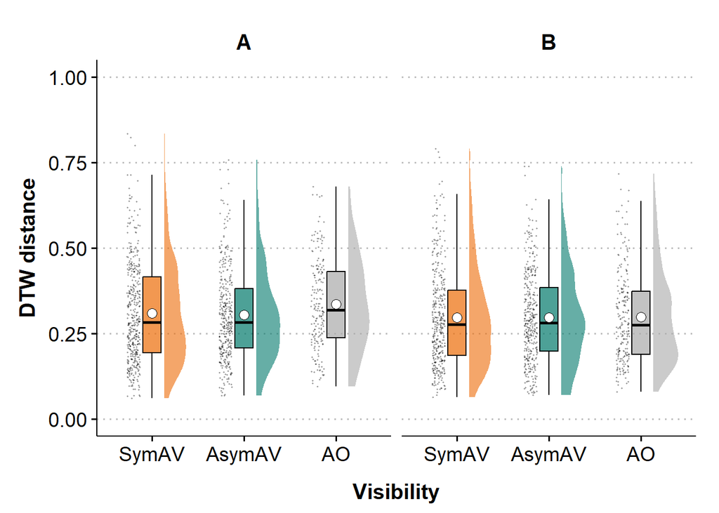

```r
rcp_distance = df_all %>%
  ggplot(aes(x = condition, y = average_distance_xyz,
             fill = condition)) +
  ggdist::stat_halfeye(adjust = 1, width = 0.3, .width = 0,
                       point_color = NA, alpha = 0.6, justification = -0.5) +
  geom_jitter(aes(x = stage(start = condition, after_scale = x - 0.2)),
              size = 0.2, alpha = 0.3, width = 0.07, height = 0) +
  geom_boxplot(width = .2,
               outlier.shape = NA,
               alpha = 0.7,
               color = "black") +
  geom_point(data = df_by_cond,
             aes(y = mean_dis),
             shape = 21, size = 3, fill = "white") +
  labs(x="Visibility",
       y="DTW distance") +
  scale_y_continuous(limits = c(0, 1)) +
  scale_fill_manual(values = c("#ED6B06", "#00786A", "darkgrey")) +
  theme_clean(base_size = 15) +
  theme(axis.text.x = element_text(colour = "black", size = 14),
        axis.text.y = element_text(colour = "black", size = 14),
        axis.title = element_text(size = 15, face = 'bold'),
        axis.title.x = element_text(vjust = -2),
        axis.title.y = element_text(vjust = 2),
        legend.position = "none",
        strip.text = element_text(size = 15, face = 'bold'),
        plot.background = element_blank(),
        plot.margin = unit(c(1.1,1.1,1.1,1.1), "lines")) +
  facet_grid(~speaker)

rcp_distance
```

### bp: dtw distance by condition

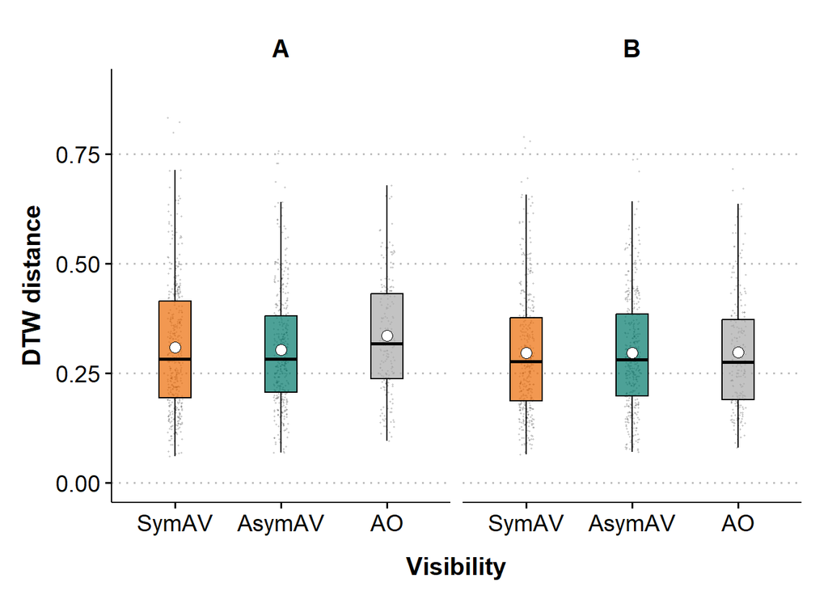

```r
bp_distance = df_all %>%
  ggplot(aes(x = condition, y = average_distance_xyz,
             fill = condition)) +
  geom_jitter(aes(x = stage(start = condition)),
              size = 0.15, alpha = 0.15, width = 0.07, height = 0) +
  geom_boxplot(width = .3,
               outlier.shape = NA,
               alpha = 0.7,
               color = "black") +
  geom_point(data = df_by_cond,
             aes(y = mean_dis),
             shape = 21, size = 3, fill = "white") +
  labs(x="Visibility",
       y="DTW distance") +
  scale_y_continuous(limits = c(0, 0.9)) +
  scale_fill_manual(values = c("#ED6B06", "#00786A", "darkgrey")) +
  theme_clean(base_size = 15) +
  theme(axis.text.x = element_text(colour = "black", size = 14),
        axis.text.y = element_text(colour = "black", size = 14),
        axis.title = element_text(size = 15, face = 'bold'),
        axis.title.x = element_text(vjust = -2),
        axis.title.y = element_text(vjust = 2),
        legend.position = "none",
        strip.text = element_text(size = 15, face = 'bold'),
        plot.background = element_blank(),
        plot.margin = unit(c(1.1,1.1,1.1,1.1), "lines")) +
  facet_grid(~speaker)

bp_distance
```

### bp: distance by condition x round

```r
bp_distance_by_cond_round =
  ggplot(df_all,
         aes(x=round, y = average_distance_xyz, fill = condition)) +
  geom_jitter(aes(x = stage(start = round)),
              size = 0.3, alpha = 0.2, width = 0.07, height = 0.02) +
  geom_boxplot(width = .5,
               outlier.shape = NA, alpha = 0.7) +
  geom_point(data = df_by_cond_round,
             aes(y = mean_dis, group = round),
             shape = 21, size = 2, fill = "white") +
  labs(x = "Round",
       y = "DTW distance") +
  scale_fill_manual(values = c("#ED6B06", "#00786A", "darkgrey")) +
  scale_y_continuous(limits = c(0, 0.9)) +
  theme_clean(base_size = 15) +
  theme(axis.text.x = element_text(colour = "black", size = 14),
        axis.text.y = element_text(colour = "black", size = 14),
        axis.title = element_text(size = 15, face = 'bold'),
        axis.title.x = element_text(vjust = -2),
        axis.title.y = element_text(vjust = 2),
        legend.position = "none",
        strip.text = element_text(size = 15, face = 'bold'),
        plot.background = element_blank(),
        plot.margin = unit(c(1.1,1.1,1.1,1.1), "lines")) +
  facet_grid(rows = vars(speaker),
             cols = vars(condition))

ggplotly(bp_distance_by_cond_round)
```

[interactive chart not shown]

## speaker B only

### rcp: dtw distance by condition

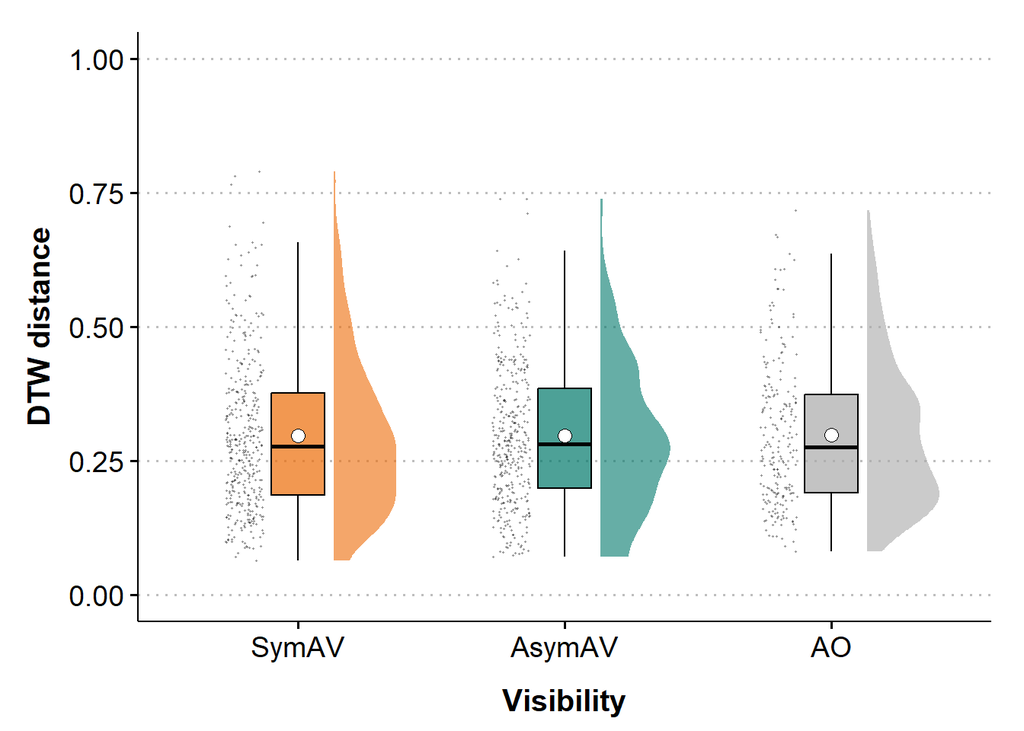

```r
rcp_distance = df %>%
  ggplot(aes(x = condition, y = average_distance_xyz,
             fill = condition)) +
  ggdist::stat_halfeye(adjust = 1, width = 0.3, .width = 0,
                       point_color = NA, alpha = 0.6, justification = -0.5) +
  geom_jitter(aes(x = stage(start = condition, after_scale = x - 0.2)),
              size = 0.2, alpha = 0.3, width = 0.07, height = 0) +
  geom_boxplot(width = .2,
               outlier.shape = NA,
               alpha = 0.7,
               color = "black") +
  geom_point(data = df_by_cond_B,
             aes(y = mean_dis),
             shape = 21, size = 3, fill = "white") +
  labs(x="Visibility",
       y="DTW distance") +
  scale_y_continuous(limits = c(0, 1)) +
  scale_fill_manual(values = c("#ED6B06", "#00786A", "darkgrey")) +
  theme_clean(base_size = 15) +
  theme(axis.text.x = element_text(colour = "black", size = 14),
        axis.text.y = element_text(colour = "black", size = 14),
        axis.title = element_text(size = 15, face = 'bold'),
        axis.title.x = element_text(vjust = -2),
        axis.title.y = element_text(vjust = 2),
        legend.position = "none",
        strip.text = element_text(size = 15, face = 'bold'),
        plot.background = element_blank(),
        plot.margin = unit(c(1.1,1.1,1.1,1.1), "lines"))

rcp_distance
```

### bp: dtw distance by condition

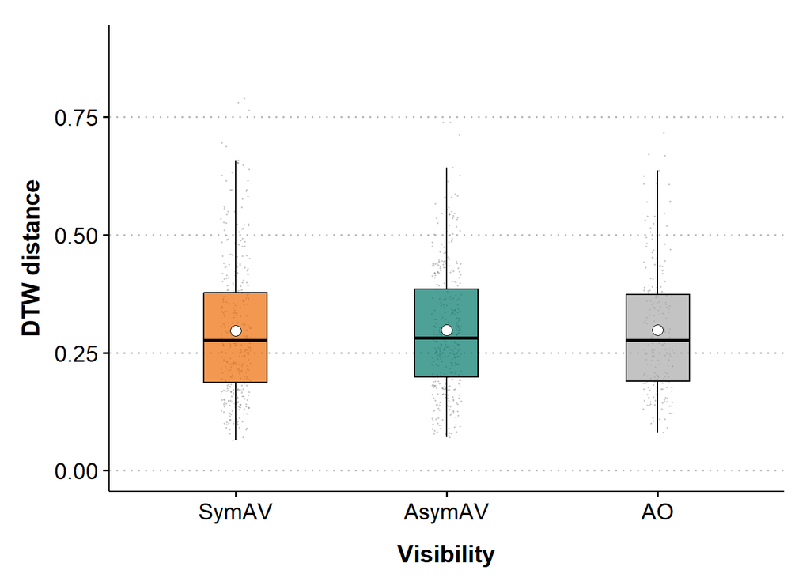

```r
bp_distance = df %>%
  ggplot(aes(x = condition, y = average_distance_xyz,
             fill = condition)) +
  geom_jitter(aes(x = stage(start = condition)),
              size = 0.15, alpha = 0.15, width = 0.07, height = 0) +
  geom_boxplot(width = .3,
               outlier.shape = NA,
               alpha = 0.7,
               color = "black") +
  geom_point(data = df_by_cond_B,
             aes(y = mean_dis),
             shape = 21, size = 3, fill = "white") +
  labs(x="Visibility",
       y="DTW distance") +
  scale_y_continuous(limits = c(0, 0.9)) +
  scale_fill_manual(values = c("#ED6B06", "#00786A", "darkgrey")) +
  theme_clean(base_size = 15) +
  theme(axis.text.x = element_text(colour = "black", size = 14),
        axis.text.y = element_text(colour = "black", size = 14),
        axis.title = element_text(size = 15, face = 'bold'),
        axis.title.x = element_text(vjust = -2),
        axis.title.y = element_text(vjust = 2),
        legend.position = "none",
        strip.text = element_text(size = 15, face = 'bold'),
        plot.background = element_blank(),
        plot.margin = unit(c(1.1,1.1,1.1,1.1), "lines"))

bp_distance
```

### bp: distance by condition x round

```r
bp_distance_by_cond_round =
  ggplot(df,
         aes(x=round, y = average_distance_xyz, fill = condition)) +
  geom_jitter(aes(x = stage(start = round)),
              size = 0.3, alpha = 0.2, width = 0.07, height = 0.02) +
  geom_boxplot(width = .5,
               outlier.shape = NA, alpha = 0.7) +
  geom_point(data = df_by_cond_round_B,
             aes(y = mean_dis, group = round),
             shape = 21, size = 2, fill = "white") +
  labs(x = "Round",
       y = "DTW distance") +
  scale_fill_manual(values = c("#ED6B06", "#00786A", "darkgrey")) +
  scale_y_continuous(limits = c(0, 0.9)) +
  theme_clean(base_size = 15) +
  theme(axis.text.x = element_text(colour = "black", size = 14),
        axis.text.y = element_text(colour = "black", size = 14),
        axis.title = element_text(size = 15, face = 'bold'),
        axis.title.x = element_text(vjust = -2),
        axis.title.y = element_text(vjust = 2),
        legend.position = "none",
        strip.text = element_text(size = 15, face = 'bold'),
        plot.background = element_blank(),
        plot.margin = unit(c(1.1,1.1,1.1,1.1), "lines")) +
  facet_grid(cols = vars(condition))

ggplotly(bp_distance_by_cond_round)
```

[interactive chart not shown]

# =====DTW distance=====

## —Causal model—

We assume the following causal model:

```r
### dag
grViz(
  "digraph {
  graph [ranksep = 0.3]
  node [shape = plaintext]
    X [label = Visibility, fontcolor = forestgreen]
    Y [label = DTW_distance, fontcolor = darkorange]
    Z [label = Round]
  edge [minlen = 2.5]
    {X -> Y
    Z -> Y}
  {rank = same; X; Y}
  }"
)
```

[interactive chart not shown]

Based on the causal inference theory, including the visibility only as fixed effects can estimate its causal effect on DTW distance. As adding rounds should not influence the estiamtes of visibility, we will include rounds as well.

## —Contrast coding—

```r
### visibility condition: difference coding
h_cond = hypr(AO_Asym = AsymAV ~ AO,
              Asym_Sym = SymAV ~ AsymAV,
              levels = levels(df$condition))
h_cond
```

```
## hypr object containing 2 null hypotheses:
##  H0.AO_Asym: 0 = AsymAV - AO
## H0.Asym_Sym: 0 = SymAV - AsymAV
##
## Call:
## hypr(AO_Asym = ~AsymAV - AO, Asym_Sym = ~SymAV - AsymAV, levels = c("SymAV",
## "AsymAV", "AO"))
##
## Hypothesis matrix (transposed):
##        AO_Asym Asym_Sym
## SymAV   0       1
## AsymAV  1      -1
## AO     -1       0
##
## Contrast matrix:
##        AO_Asym Asym_Sym
## SymAV   1/3     2/3
## AsymAV  1/3    -1/3
## AO     -2/3    -1/3
```

```r
contrasts(df$condition) = contr.hypothesis(h_cond)


### visibility condition: treatment coding
h_cond = hypr(AO_Sym = SymAV ~ AO,
              Asym_Sym = SymAV ~ AsymAV,
              levels = levels(df$condition))
h_cond
```

```
## hypr object containing 2 null hypotheses:
##   H0.AO_Sym: 0 = SymAV - AO
## H0.Asym_Sym: 0 = SymAV - AsymAV
##
## Call:
## hypr(AO_Sym = ~SymAV - AO, Asym_Sym = ~SymAV - AsymAV, levels = c("SymAV",
## "AsymAV", "AO"))
##
## Hypothesis matrix (transposed):
##        AO_Sym Asym_Sym
## SymAV   1      1
## AsymAV  0     -1
## AO     -1      0
##
## Contrast matrix:
##        AO_Sym Asym_Sym
## SymAV   1/3    1/3
## AsymAV  1/3   -2/3
## AO     -2/3    1/3
```

```r
contrasts(df$condition_sum) = contr.hypothesis(h_cond)
```

## Log-normal regressions

### Prior specification

The mediapipe estimates the locations of each keypoint in the video frame with a number between 0 (top, left) and 1 (bottom, right). As we use normalized dtw distance in which the sum of the distance is normalized by the duration of the annotated gestures, we can assume that most of the dtw distances should be between 0 and 1. Therefore, we expect the mean dtw distance to be around 0.5 and the most likely range of the dtw distance to be between 0 and 1.

Given that the dtw distance cannot be negative, it is not optimal to model the dtw distance with a normal distribution (linear regression). Instead, we will use a log-normal distribution to model the dtw distance. The log-normal distribution is a continuous probability distribution of a random variable whose logarithm is normally distributed. The log-normal distribution is a good choice for modeling the dtw distance because it is always positive and has a long tail to the right.

As for the fixed effects, we will set unbiased priors of Normal(0, 0.2). This means that when the mean distance score is 0.5, we expect it to change to 0.33 (exp(-1.1)) or 0.74 (exp(-0.3)) when x increased by 1 (e.g., contrast between AO–AsymAV conditions). This prior is “unbiased” because we are telling the model that most likely values for the slopes are around 0 (i.e., no effect).

We will use LKJ(2) prior for the correlation matrix.

```r
priors_rint_dtw = c(
  prior(normal(-0.7, 0.5), class = Intercept),
  prior(normal(0, 0.2), class = b),
  prior(normal(0, 0.2), class = sd),
  prior(normal(0, 0.5), class = sigma))

priors_rslope_dtw = c(
  prior(normal(-0.7, 0.5), class = Intercept),
  prior(normal(0, 0.2), class = b),
  prior(normal(0, 0.2), class = sd),
  prior(normal(0, 0.5), class = sigma),
  prior(lkj(2), class = cor))
```

### Model 1: [ppB] condition * round_c

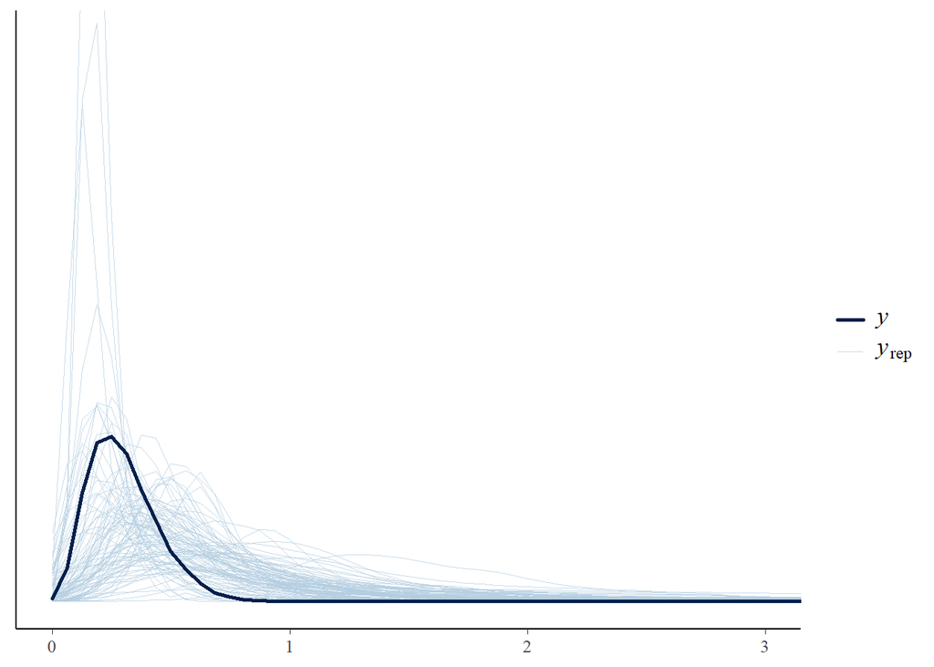

```r
mln_dtw_prior = brm(average_distance_xyz ~ 1 + condition * round_c +
                      (1+round_c|pair) + (1|target),
                    family = lognormal(),
                    prior = priors_rslope_dtw,
                    sample_prior = "only",
                    data = df,
                    file = "models/speakerB/mln_dtw_prior")

pp_check(mln_dtw_prior, ndraws = 100) +
  coord_cartesian(xlim = c(0, 3),
                  ylim = c(0, 10))
```

The prior predictive check shows that the model is able to generate data that is consistent with the observed data.

#### Fit the model

```r
mln_dtw = brm(average_distance_xyz ~ 1 + condition * round_c +
                (1+round_c|pair) + (1|target),
              family = lognormal(),
              prior = priors_rslope_dtw,
              data = df,
              sample_prior = T,
              warmup = nwu, iter = niter,
              control = list(adapt_delta = 0.9,
                             max_treedepth = 15),
              file = "models/speakerB/mln_dtw")

model = mln_dtw
summary(model)
```

```
##  Family: lognormal
##   Links: mu = identity; sigma = identity
## Formula: average_distance_xyz ~ 1 + condition * round_c + (1 + round_c | pair) + (1 | target)
##    Data: df (Number of observations: 983)
##   Draws: 4 chains, each with iter = 20000; warmup = 2000; thin = 1;
##          total post-warmup draws = 72000
##
## Multilevel Hyperparameters:
## ~pair (Number of levels: 41)
##                        Estimate Est.Error l-95% CI u-95% CI Rhat Bulk_ESS
## sd(Intercept)              0.14      0.03     0.09     0.20 1.00    29299
## sd(round_c)                0.06      0.02     0.03     0.10 1.00    24044
## cor(Intercept,round_c)     0.16      0.28    -0.40     0.68 1.00    35839
##                        Tail_ESS
## sd(Intercept)             47194
## sd(round_c)               28965
## cor(Intercept,round_c)    46479
##
## ~target (Number of levels: 16)
##               Estimate Est.Error l-95% CI u-95% CI Rhat Bulk_ESS Tail_ESS
## sd(Intercept)     0.06      0.03     0.01     0.12 1.00    20462    18422
##
## Regression Coefficients:
##                           Estimate Est.Error l-95% CI u-95% CI Rhat Bulk_ESS
## Intercept                    -1.29      0.04    -1.36    -1.22 1.00    33208
## conditionAO_Asym             -0.04      0.07    -0.18     0.11 1.00    34927
## conditionAsym_Sym            -0.05      0.07    -0.18     0.08 1.00    31118
## round_c                       0.02      0.02    -0.01     0.06 1.00    49235
## conditionAO_Asym:round_c     -0.06      0.04    -0.14     0.02 1.00    44712
## conditionAsym_Sym:round_c     0.03      0.04    -0.04     0.10 1.00    42734
##                           Tail_ESS
## Intercept                    42185
## conditionAO_Asym             44018
## conditionAsym_Sym            39827
## round_c                      49784
## conditionAO_Asym:round_c     49217
## conditionAsym_Sym:round_c    46861
##
## Further Distributional Parameters:
##       Estimate Est.Error l-95% CI u-95% CI Rhat Bulk_ESS Tail_ESS
## sigma     0.46      0.01     0.44     0.48 1.00    79971    53587
##
## Draws were sampled using sample(hmc). For each parameter, Bulk_ESS
## and Tail_ESS are effective sample size measures, and Rhat is the potential
## scale reduction factor on split chains (at convergence, Rhat = 1).
```

```r
bayestestR::hdi(model)
```

|  | Parameter | CI | CI_low | CI_high | Effects | Component |
| --- | --- | --- | --- | --- | --- | --- |
| 5 | b_Intercept | 0.95 | -1.36080 | -1.2222 | fixed | conditional |
| 1 | b_conditionAO_Asym | 0.95 | -0.17703 | 0.1048 | fixed | conditional |
| 3 | b_conditionAsym_Sym | 0.95 | -0.17971 | 0.0825 | fixed | conditional |
| 6 | b_round_c | 0.95 | -0.00923 | 0.0580 | fixed | conditional |
| 2 | b_conditionAO_Asym:round_c | 0.95 | -0.14366 | 0.0227 | fixed | conditional |
| 4 | b_conditionAsym_Sym:round_c | 0.95 | -0.04204 | 0.1033 | fixed | conditional |

```r
# bayestestR::hdi(model, ci = 0.89)
```

The coefficients show that the visibility condition did not have a reliable effect on the dtw distance.

#### Visualize the posterior distributions

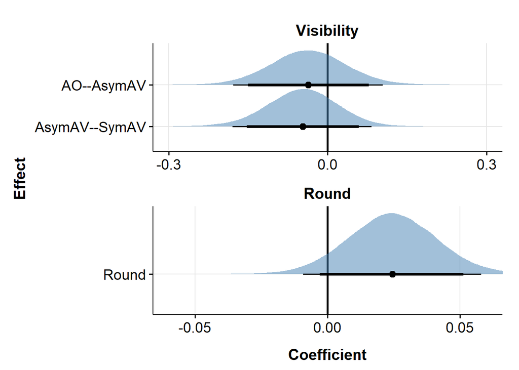

```r
plot_posterior(model)
```

#### Prior-posterior update plot

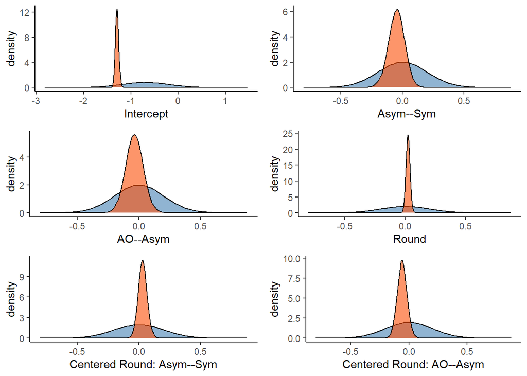

```r
post_sample = as_draws_df(model)
pp_update_plot(post_sample)
```

#### Posterior predictive check

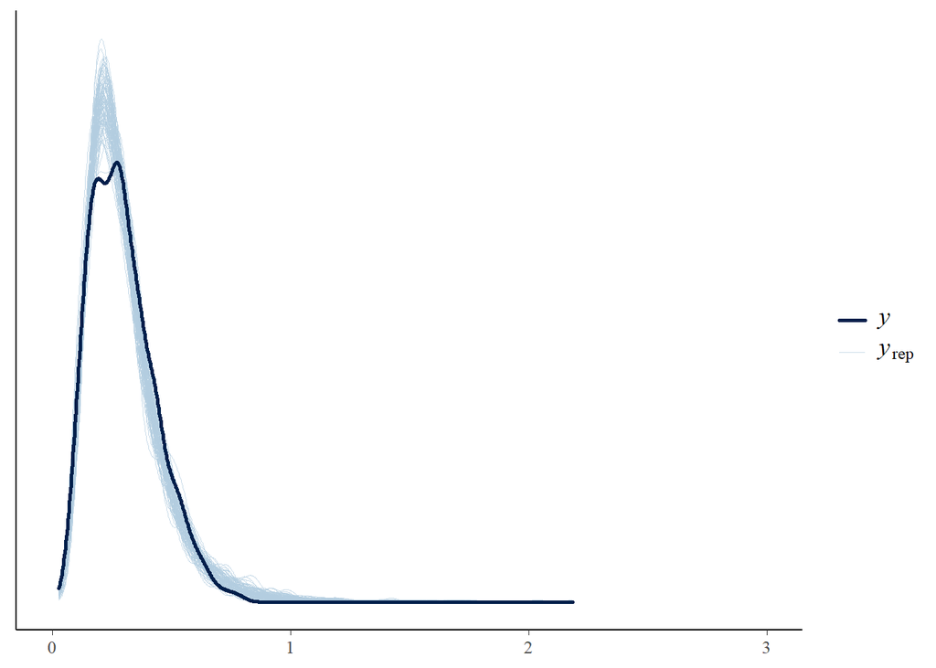

```r
pp_check(model, ndraws = 100) +
  coord_cartesian(xlim = c(0, 3))
```

The posterior predictive check shows that the model is able to generate data that is overall consistent with the observed data.

#### Hypothesis testing: Bayes factor

```r
### varying priors for sensitivity analysis
prior_size = c("xs", "s", "l", "xl")
prior_sd = c(0.05, 0.1, 0.3, 0.5)
bfs_cond_ao_asym = c()
bfs_cond_asym_sym = c()
bfs_round = c()
bfs_ao_asym_round = c()
bfs_asym_sym_round = c()

for (i in 1:length(prior_sd)){
  priors = c(
    prior(normal(-0.7, 0.5), class = Intercept),
    set_prior(paste0("normal(0,", prior_sd[i], ")"), class = "b"),
    prior(normal(0, 0.2), class = sd),
    prior(normal(0, 0.5), class = sigma),
    prior(lkj(2), class = cor))

  fname = paste0("models/speakerB/mln_dtw_", prior_size[i])

  fit = brm(average_distance_xyz ~ 1 + condition * round_c +
              (1+round_c|pair) + (1|target),
            family = lognormal(),
            prior = priors,
            data = df,
            sample_prior = T,
            save_pars = save_pars(all = TRUE),
            warmup = nwu, iter = niter,
            control = list(adapt_delta = 0.9,
                           max_treedepth = 15),
            file = fname)

  ### BF for visibility conditions
  # sym - asym
  h = hypothesis(fit, "conditionAO_Asym = 0")
  bf = 1 / abs(h$hypothesis$Evid.Ratio)
  bfs_cond_ao_asym = c(bfs_cond_ao_asym, bf)

  # sym - ao
  h = hypothesis(fit, "conditionAsym_Sym = 0")
  bf = 1 / abs(h$hypothesis$Evid.Ratio)
  bfs_cond_asym_sym = c(bfs_cond_asym_sym, bf)

  ### BF for rounds
  h = hypothesis(model, "round_c = 0")
  bf = 1 / abs(h$hypothesis$Evid.Ratio)
  bfs_round = c(bfs_round, bf)

  ### BF for interaction
  # ao - asym: round
  h = hypothesis(model, "conditionAO_Asym:round_c = 0")
  bf = 1 / abs(h$hypothesis$Evid.Ratio)
  bfs_ao_asym_round = c(bfs_ao_asym_round, bf)

  # asym - sym: round
  h = hypothesis(model, "conditionAsym_Sym:round_c = 0")
  bf = 1 / abs(h$hypothesis$Evid.Ratio)
  bfs_asym_sym_round = c(bfs_asym_sym_round, bf)
}

### add BF for the main/medium model
prior_size[3:5] = c("m", prior_size[3:4])
prior_sd[3:5] = c(0.2, prior_sd[3:4])

### BF for visibility
# sym - asym
h = hypothesis(model, "conditionAO_Asym = 0")
bf = 1 / abs(h$hypothesis$Evid.Ratio)
bfs_cond_ao_asym[3:5] = c(bf, bfs_cond_ao_asym[3:4])

# sym - ao
h = hypothesis(model, "conditionAsym_Sym = 0")
bf = 1 / abs(h$hypothesis$Evid.Ratio)
bfs_cond_asym_sym[3:5] = c(bf, bfs_cond_asym_sym[3:4])

### BF for rounds
h = hypothesis(model, "round_c = 0")
bf = 1 / abs(h$hypothesis$Evid.Ratio)
bfs_round[3:5] = c(bf, bfs_round[3:4])

### BF for interaction
# ao - asym: round
h = hypothesis(model, "conditionAO_Asym:round_c = 0")
bf = 1 / abs(h$hypothesis$Evid.Ratio)
bfs_ao_asym_round[3:5] = c(bf, bfs_ao_asym_round[3:4])

# asym - sym: round
h = hypothesis(model, "conditionAsym_Sym:round_c = 0")
bf = 1 / abs(h$hypothesis$Evid.Ratio)
bfs_asym_sym_round[3:5] = c(bf, bfs_asym_sym_round[3:4])


### make a df for BFs
df_bf = data.frame(size = prior_size,
                   sd = prior_sd,
                   ao_asym = bfs_cond_ao_asym,
                   asym_sym = bfs_cond_asym_sym,
                   round = bfs_round,
                   ao_asym_round = bfs_ao_asym_round,
                   asym_sym_round = bfs_asym_sym_round) %>%
  mutate(prior = paste0("N(0, ", sd, ")")) %>%
  pivot_longer(cols = c("ao_asym", "asym_sym", "round",
                        "ao_asym_round", "asym_sym_round"),
               names_to = "Effect",
               values_to = "BF10") %>%
  mutate(Predictor = ifelse(grepl("_round", Effect), "Interaction",
                            ifelse(grepl("round", Effect), "Round", "Visibility")))

df_bf$Effect = recode(df_bf$Effect,
                      ao_asym = "AO--AsymAV",
                      asym_sym = "AsymAV--SymAV",
                      round = "Round",
                      ao_asym_round = "AO--AsymAV:Round",
                      asym_sym_round = "AsymAV--SymAV:Round")
```

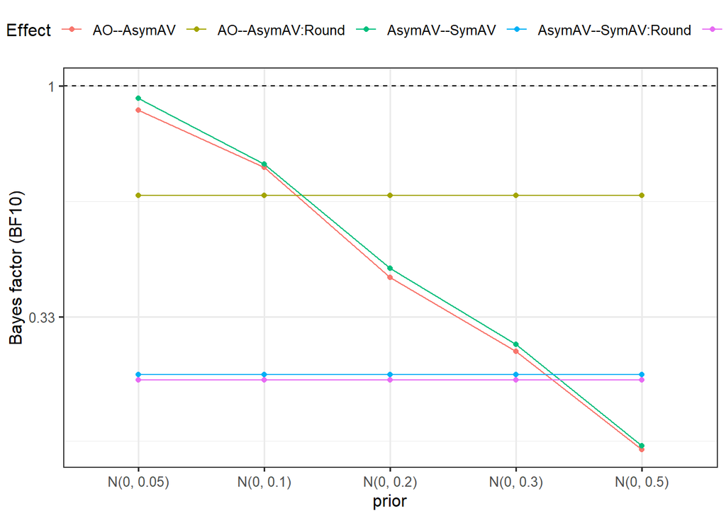

```r
#### Plot BFs ####
ggplot(df_bf, aes(x = prior, y = BF10, group = Effect)) +
   geom_hline(yintercept = 1, linetype="dashed") +
   geom_point(aes(color=Effect)) +
   geom_line(aes(color=Effect)) +
   theme_bw(base_size = 12)+
   theme(legend.position = "top")+
   scale_y_log10("Bayes factor (BF10)",
                 breaks = c(0.001, 0.01, 0.03, 0.1, 0.33, 1, 3, 10, 30, 100, 1e4, 1e5, 1e6, 1e7),
                 labels = c(0.001, 0.01, 0.03, 0.1, 0.33, 1, 3, 10, 30, 100, 1e4, 1e5, 1e6, 1e7)) +
   xlab("prior")
```

#### Probability of direction

```r
p_direction(model)
```

|  | Parameter | pd | Effects | Component |
| --- | --- | --- | --- | --- |
| 5 | b_Intercept | 1.000 | fixed | conditional |
| 1 | b_conditionAO_Asym | 0.698 | fixed | conditional |
| 3 | b_conditionAsym_Sym | 0.768 | fixed | conditional |
| 6 | b_round_c | 0.926 | fixed | conditional |
| 2 | b_conditionAO_Asym:round_c | 0.921 | fixed | conditional |
| 4 | b_conditionAsym_Sym:round_c | 0.798 | fixed | conditional |

#### Pair-wise comparison

```r
emmeans(model, pairwise ~ condition)$contrasts
```

```
##  contrast       estimate lower.HPD upper.HPD
##  SymAV - AsymAV  -0.0455    -0.176    0.0878
##  SymAV - AO      -0.0850    -0.231    0.0567
##  AsymAV - AO     -0.0395    -0.180    0.1027
##
## Point estimate displayed: median
## HPD interval probability: 0.95
```

```r
emmeans(model, pairwise ~ condition, level = 0.89)$contrasts
```

```
##  contrast       estimate lower.HPD upper.HPD
##  SymAV - AsymAV  -0.0455    -0.152    0.0598
##  SymAV - AO      -0.0850    -0.204    0.0294
##  AsymAV - AO     -0.0395    -0.154    0.0751
##
## Point estimate displayed: median
## HPD interval probability: 0.89
```

### Model 2: [ppB] condition_sum * round_c

[figure not shown]

```r
mln_dtw_sum_prior = brm(average_distance_xyz ~ 1 + condition_sum * round_c +
                          (1+round_c|pair) + (1|target),
                        family = lognormal(),
                        prior = priors_rslope_dtw,
                        sample_prior = "only",
                        data = df,
                        file = "models/speakerB/mln_dtw_sum_prior")

pp_check(mln_dtw_sum_prior, ndraws = 100) +
  coord_cartesian(xlim = c(0, 3),
                  ylim = c(0, 10))
```

The prior predictive check shows that the model is able to generate data that is consistent with the observed data.

#### Fit the model

```r
mln_dtw_sum = brm(average_distance_xyz ~ 1 + condition_sum * round_c +
                    (1+round_c|pair) + (1|target),
                  family = lognormal(),
                  prior = priors_rslope_dtw,
                  data = df,
                  sample_prior = T,
                  warmup = nwu, iter = niter,
                  control = list(adapt_delta = 0.9,
                                 max_treedepth = 15),
                  file = "models/speakerB/mln_dtw_sum")

model1 = mln_dtw
model = mln_dtw_sum
summary(model)
```

```
##  Family: lognormal
##   Links: mu = identity; sigma = identity
## Formula: average_distance_xyz ~ 1 + condition_sum * round_c + (1 + round_c | pair) + (1 | target)
##    Data: df (Number of observations: 983)
##   Draws: 4 chains, each with iter = 20000; warmup = 2000; thin = 1;
##          total post-warmup draws = 72000
##
## Multilevel Hyperparameters:
## ~pair (Number of levels: 41)
##                        Estimate Est.Error l-95% CI u-95% CI Rhat Bulk_ESS
## sd(Intercept)              0.14      0.03     0.09     0.20 1.00    27225
## sd(round_c)                0.06      0.02     0.03     0.10 1.00    23476
## cor(Intercept,round_c)     0.16      0.28    -0.40     0.68 1.00    31498
##                        Tail_ESS
## sd(Intercept)             43284
## sd(round_c)               28995
## cor(Intercept,round_c)    43412
##
## ~target (Number of levels: 16)
##               Estimate Est.Error l-95% CI u-95% CI Rhat Bulk_ESS Tail_ESS
## sd(Intercept)     0.06      0.03     0.01     0.12 1.00    19242    16092
##
## Regression Coefficients:
##                               Estimate Est.Error l-95% CI u-95% CI Rhat
## Intercept                        -1.29      0.03    -1.36    -1.22 1.00
## condition_sumAO_Sym              -0.08      0.07    -0.21     0.06 1.00
## condition_sumAsym_Sym            -0.04      0.07    -0.17     0.09 1.00
## round_c                           0.02      0.02    -0.01     0.06 1.00
## condition_sumAO_Sym:round_c      -0.03      0.04    -0.11     0.05 1.00
## condition_sumAsym_Sym:round_c     0.03      0.04    -0.04     0.10 1.00
##                               Bulk_ESS Tail_ESS
## Intercept                        28963    39746
## condition_sumAO_Sym              30698    43246
## condition_sumAsym_Sym            27299    39085
## round_c                          41461    45702
## condition_sumAO_Sym:round_c      41462    45800
## condition_sumAsym_Sym:round_c    36532    43460
##
## Further Distributional Parameters:
##       Estimate Est.Error l-95% CI u-95% CI Rhat Bulk_ESS Tail_ESS
## sigma     0.46      0.01     0.44     0.48 1.00    68633    53545
##
## Draws were sampled using sample(hmc). For each parameter, Bulk_ESS
## and Tail_ESS are effective sample size measures, and Rhat is the potential
## scale reduction factor on split chains (at convergence, Rhat = 1).
```

```r
bayestestR::hdi(model)
```

|  | Parameter | CI | CI_low | CI_high | Effects | Component |
| --- | --- | --- | --- | --- | --- | --- |
| 5 | b_Intercept | 0.95 | -1.3595 | -1.2229 | fixed | conditional |
| 1 | b_condition_sumAO_Sym | 0.95 | -0.2124 | 0.0604 | fixed | conditional |
| 3 | b_condition_sumAsym_Sym | 0.95 | -0.1720 | 0.0885 | fixed | conditional |
| 6 | b_round_c | 0.95 | -0.0093 | 0.0583 | fixed | conditional |
| 2 | b_condition_sumAO_Sym:round_c | 0.95 | -0.1131 | 0.0528 | fixed | conditional |
| 4 | b_condition_sumAsym_Sym:round_c | 0.95 | -0.0418 | 0.1032 | fixed | conditional |

```r
# bayestestR::hdi(model, ci = 0.89)
```

The coefficients show that the visibility condition did not have a reliable effect on the dtw distance.

#### Visualize the posterior distributions

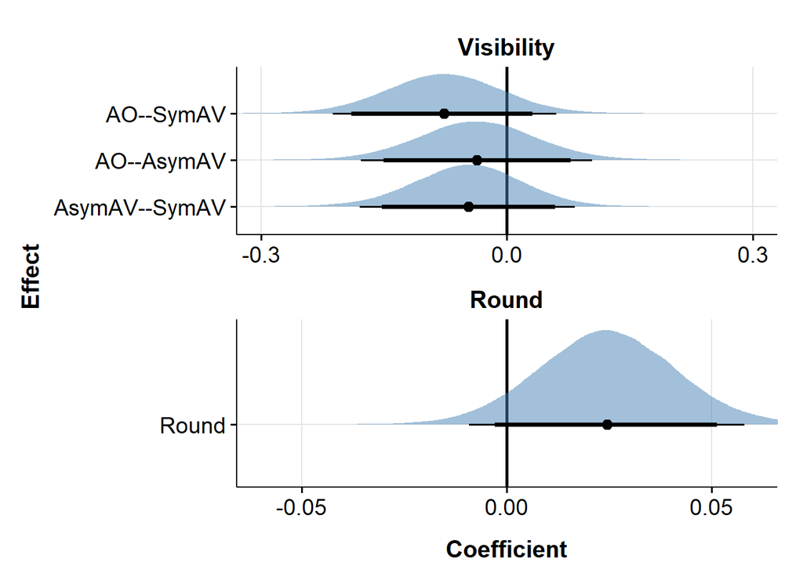

```r
plot_posterior(model1, model)
```

#### Prior-posterior update plot

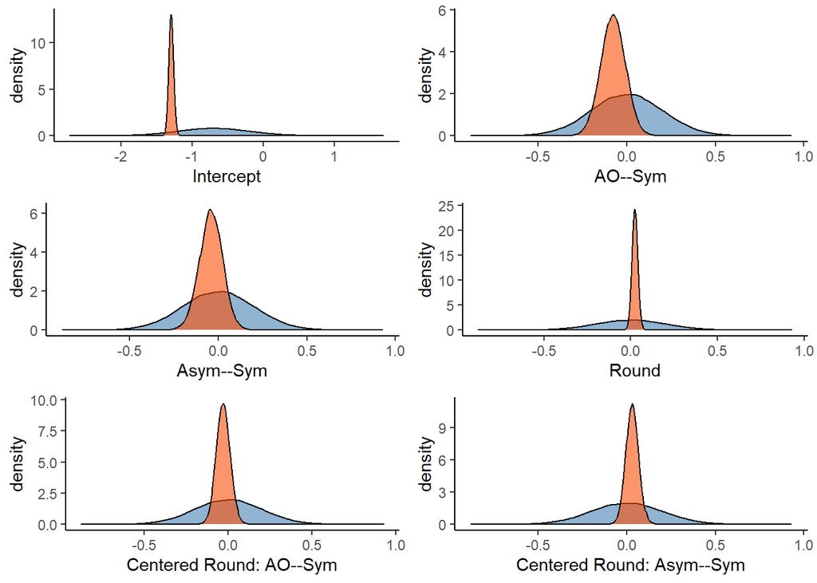

```r
post_sample = as_draws_df(model)
pp_update_plot(post_sample, interaction = T)
```

#### Posterior predictive check

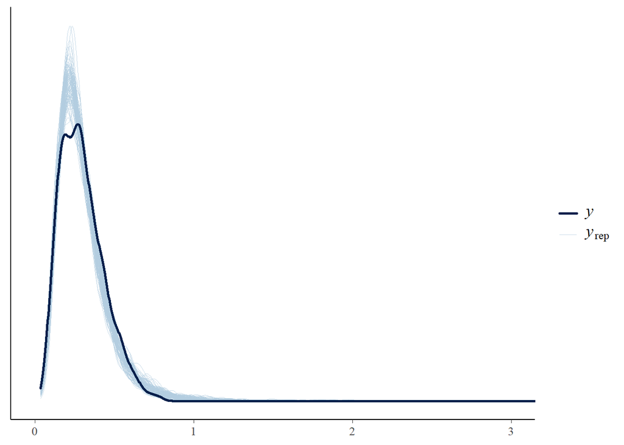

```r
pp_check(model, ndraws = 100) +
  coord_cartesian(xlim = c(0, 3))
```

The posterior predictive check shows that the model is able to generate data that is overall consistent with the observed data.

#### Hypothesis testing: Bayes factor

```r
### varying priors for sensitivity analysis
prior_size = c("xs", "s", "l", "xl")
prior_sd = c(0.05, 0.1, 0.3, 0.5)
bfs_cond_ao_sym = c()
bfs_ao_sym_round = c()

for (i in 1:length(prior_sd)){
  priors = c(
    prior(normal(-0.7, 0.5), class = Intercept),
    set_prior(paste0("normal(0,", prior_sd[i], ")"), class = "b"),
    prior(normal(0, 0.2), class = sd),
    prior(normal(0, 0.5), class = sigma),
    prior(lkj(2), class = cor))

  fname = paste0("models/speakerB/mln_dtw_sum_", prior_size[i])

  fit = brm(average_distance_xyz ~ 1 + condition_sum * round_c +
              (1+round_c|pair) + (1|target),
            family = lognormal(),
            prior = priors,
            data = df,
            sample_prior = T,
            save_pars = save_pars(all = TRUE),
            warmup = nwu, iter = niter,
            control = list(adapt_delta = 0.9,
                           max_treedepth = 15),
            file = fname)

  # BF for sym - ao
  h = hypothesis(fit, "condition_sumAO_Sym = 0")
  bf = 1 / abs(h$hypothesis$Evid.Ratio)
  bfs_cond_ao_sym = c(bfs_cond_ao_sym, bf)

  ### BF for interaction
  # ao - sym: round
  h = hypothesis(model, "condition_sumAO_Sym:round_c = 0")
  bf = 1 / abs(h$hypothesis$Evid.Ratio)
  bfs_ao_sym_round = c(bfs_ao_sym_round, bf)
}

### add BF for the main/medium model
prior_size[3:5] = c("m", prior_size[3:4])
prior_sd[3:5] = c(0.2, prior_sd[3:4])

# BF for sym - ao
h = hypothesis(model, "condition_sumAO_Sym = 0")
bf = 1 / abs(h$hypothesis$Evid.Ratio)
bfs_cond_ao_sym[3:5] = c(bf, bfs_cond_ao_sym[3:4])

# ao - sym: round
h = hypothesis(model, "condition_sumAO_Sym:round_c = 0")
bf = 1 / abs(h$hypothesis$Evid.Ratio)
bfs_ao_sym_round[3:5] = c(bf, bfs_ao_sym_round[3:4])


### make a df for BFs
df_bf_temp = data.frame(size = prior_size,
                   sd = prior_sd,
                   ao_sym = bfs_cond_ao_sym,
                   ao_sym_round = bfs_ao_sym_round) %>%
  mutate(prior = paste0("N(0, ", sd, ")")) %>%
  pivot_longer(cols = c("ao_sym", "ao_sym_round"),
               names_to = "Effect",
               values_to = "BF10") %>%
  mutate(Predictor = ifelse(grepl("_round", Effect), "Interaction", "Visibility"))

df_bf_temp$Effect = recode(df_bf_temp$Effect,
                           ao_sym = "AO--SymAV",
                           ao_sym_round = "AO--SymAV:Round")


df_bf_new = df_bf %>%
  rbind(df_bf_temp) %>%
  mutate(Effect = factor(Effect,
                         levels = c("AO--SymAV", "AO--AsymAV", "AsymAV--SymAV", "Round",
                                    "AO--SymAV:Round", "AO--AsymAV:Round", "AsymAV--SymAV:Round")),
         Predictor = factor(Predictor,
                            levels = c("Visibility", "Round", "Interaction")))

df_bf_new %>% arrange(Effect, sd)
```

| size | sd | prior | Effect | BF10 | Predictor |
| --- | --- | --- | --- | --- | --- |
| xs | 0.05 | N(0, 0.05) | AO--SymAV | 0.982 | Visibility |
| s | 0.10 | N(0, 0.1) | AO--SymAV | 0.885 | Visibility |
| m | 0.20 | N(0, 0.2) | AO--SymAV | 0.617 | Visibility |
| l | 0.30 | N(0, 0.3) | AO--SymAV | 0.465 | Visibility |
| xl | 0.50 | N(0, 0.5) | AO--SymAV | 0.295 | Visibility |
| xs | 0.05 | N(0, 0.05) | AO--AsymAV | 0.889 | Visibility |
| s | 0.10 | N(0, 0.1) | AO--AsymAV | 0.676 | Visibility |
| m | 0.20 | N(0, 0.2) | AO--AsymAV | 0.399 | Visibility |
| l | 0.30 | N(0, 0.3) | AO--AsymAV | 0.279 | Visibility |
| xl | 0.50 | N(0, 0.5) | AO--AsymAV | 0.174 | Visibility |

[output cut: 25 more lines]

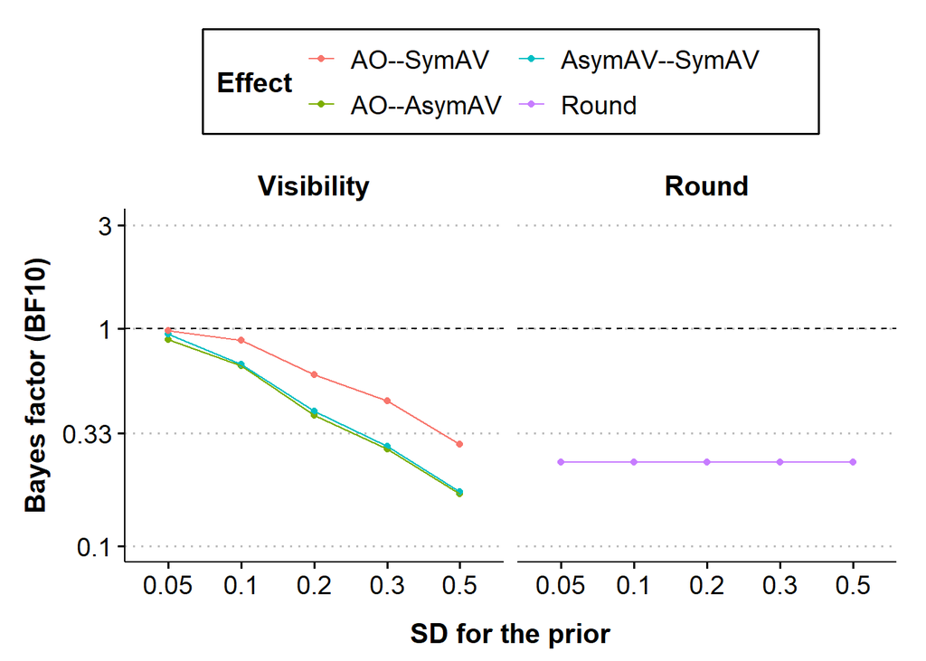

```r
#### Plot BFs ####
ggplot(filter(df_bf_new, Predictor != "Interaction"),
       aes(x = factor(sd), y = BF10, group = Effect)) +
  geom_hline(yintercept = 1, linetype="dashed") +
  geom_point(aes(color=Effect)) +
  geom_line(aes(color=Effect)) +
  facet_wrap(vars(Predictor)) +
  theme_clean(base_size = 15) +
  theme(axis.text.x = element_text(colour = "black", size = 14),
        axis.text.y = element_text(colour = "black", size = 14),
        axis.title = element_text(size = 15, face = 'bold'),
        axis.title.x = element_text(vjust = -2),
        axis.title.y = element_text(vjust = 2),
        legend.position = "top",
        strip.text = element_text(size = 15, face = 'bold'),
        plot.background = element_blank(),
        plot.margin = unit(c(1.1,1.1,1.1,1.1), "lines")) +
  scale_y_log10("Bayes factor (BF10)",
                limits = c(0.1, 3),
                breaks = c(0.001, 0.03, 0.01, 0.1, 0.33, 1, 3, 10, 30, 100),
                labels = c(0.001, 0.03, 0.01, 0.1, 0.33, 1, 3, 10, 30, 100)) +
  guides(color = guide_legend(ncol = 3)) +
  xlab("SD for the prior")
```

#### Probability of direction

```r
p_direction(model)
```

|  | Parameter | pd | Effects | Component |
| --- | --- | --- | --- | --- |
| 5 | b_Intercept | 1.000 | fixed | conditional |
| 1 | b_condition_sumAO_Sym | 0.867 | fixed | conditional |
| 3 | b_condition_sumAsym_Sym | 0.735 | fixed | conditional |
| 6 | b_round_c | 0.928 | fixed | conditional |
| 2 | b_condition_sumAO_Sym:round_c | 0.768 | fixed | conditional |
| 4 | b_condition_sumAsym_Sym:round_c | 0.807 | fixed | conditional |